# Full-bridge converter

The full-bridge converter shown in the figure is operated at a switching frequency of $50\,$kHz. The input voltage of $50\,$V, $L=1\,$mH, $C=10\,\mu$F, $R=50\,\Omega$. The magnetizing inductance as seen from the primary is $100\,\mu$H, and $N_1:N_2:N_3$ is $1:10:10$ for the transformer. The switches are operated in a phase-modulated manner as shown in the figure.

1. What is the output voltage?
2. Find the inductor current ripple and ripple frequency.
3. Plot the transformer primary voltage and current waveforms.

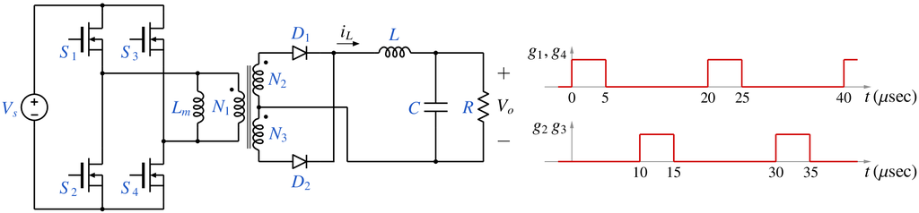

```python
from IPython.display import Image
Image(filename =r'bridge_dcdc_2_fig_1.png', width=850)
```

```python
# run this cell to view the circuit file.
%pycat bridge_dcdc_2_orig.in
```

We now replace the strings such as \$Vdc, \$L, with the values of our choice by running the python script given below. It takes an existing circuit file `bridge_dcdc_2_orig.in` and produces a new circuit file `bridge_dcdc_2.in`, after replacing \$Vdc, \$L, etc. with values of our choice.

```python
import gseim_calc as calc
s_Vdc = "50"
s_Lm = "100e-6"
s_L = "1e-3"
s_R = "50"
s_C = "10e-6"
s_N1 = "1"
s_N2 = "10"
s_N3 = "10"

f_hz = 50.0e3
T = 1/f_hz
s_Tend = "20e-3"
Tend = float(s_Tend)
T1 = Tend - 2.0*T
s_T1 = ("%11.4E"%(T1)).strip()

l = [
  ('$Vdc', s_Vdc),
  ('$Lm', s_Lm),
  ('$L', s_L),
  ('$R', s_R),
  ('$C', s_C),
  ('$N1', s_N1),
  ('$N2', s_N2),
  ('$N3', s_N3),
  ('$Tend', s_Tend),
  ('$T1', s_T1),
]
calc.replace_strings_1("bridge_dcdc_2_orig.in", "bridge_dcdc_2.in", l)
print('bridge_dcdc_2.in is ready for execution')
```

```
bridge_dcdc_2.in is ready for execution
```

**Execute the following cell to run GSEIM on bridge_dcdc_2.in.**

```python
import os
import dos_unix
# uncomment for windows:
#dos_unix.d2u("bridge_dcdc_2.in")
os.system('run_gseim bridge_dcdc_2.in')
```

```
Circuit: filename = bridge_dcdc_2.in
main: calling solve_trns
Transient simulation starts...
i=0
i=10000
i=20000
i=30000
i=40000
i=50000
i=60000
i=70000
i=80000
i=90000
i=100000
GSEIM: Program completed.
```

```
0
```

```
filename: bridge_dcdc_2_1.dat
filename: bridge_dcdc_2_2.dat
peak-to-peak ripple in IL:  1.2517E+00
```

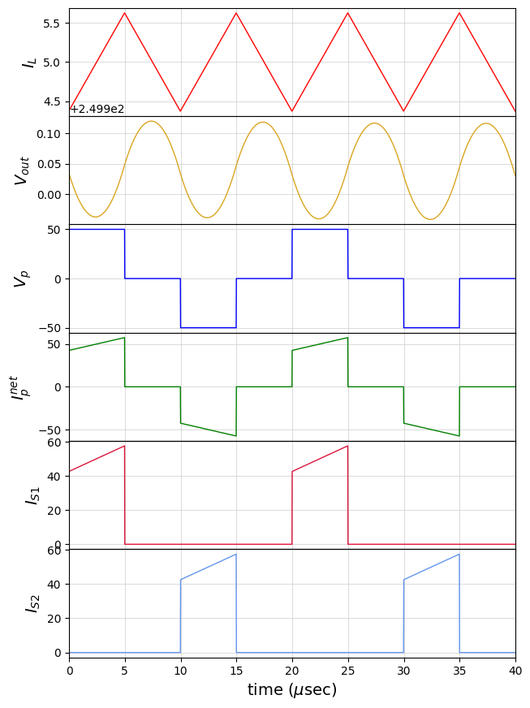

```python
import numpy as np
import matplotlib.pyplot as plt
import gseim_calc as calc
from setsize import set_size

f_hz = 50.0e3
T = 1.0/f_hz

slv = calc.slv("bridge_dcdc_2.in")

i_slv = 0
i_out = 0
filename = slv.l_filename_all[i_slv][i_out]
print('filename:', filename)
u1 = np.loadtxt(filename)
t1a = u1[:, 0]
t1 = t1a - t1a[0]

v_out = slv.get_array_double(i_slv,i_out,"v_out",u1)
IL    = slv.get_array_double(i_slv,i_out,"IL",u1)
ILm   = slv.get_array_double(i_slv,i_out,"ILm",u1)
ip    = slv.get_array_double(i_slv,i_out,"ip",u1)
vp    = slv.get_array_double(i_slv,i_out,"vp",u1)

ip_net = ILm + ip

i_out = 1
filename = slv.l_filename_all[i_slv][i_out]
print('filename:', filename)
u2 = np.loadtxt(filename)
t2a = u2[:, 0]
t2 = t2a - t2a[0]

IS1 = slv.get_array_double(i_slv,i_out,"IS1",u2)
IS2 = slv.get_array_double(i_slv,i_out,"IS2",u2)

l_IL_1 = calc.min_max_1(t1, IL, 0.0, 2.0*T)
IL_ptop = l_IL_1[1] - l_IL_1[0]
print('peak-to-peak ripple in IL:', "%11.4E"%IL_ptop)

color1='red'
color2='goldenrod'
color3='blue'
color4='green'
color5='crimson'
color6='cornflowerblue'

fig, ax = plt.subplots(6, sharex=False)
plt.subplots_adjust(wspace=0, hspace=0.0)

set_size(5.5, 8, ax[0])

for i in range(6):
    ax[i].set_xlim(left=0.0, right=2.0*T*1e6)
    ax[i].grid(color='#CCCCCC', linestyle='solid', linewidth=0.5)

ax[0].set_ylabel(r'$I_L$'      , fontsize=14)
ax[1].set_ylabel(r'$V_{out}$'  , fontsize=14)
ax[2].set_ylabel(r'$V_p$'      , fontsize=14)
ax[3].set_ylabel(r'$I_p^{net}$', fontsize=14)
ax[4].set_ylabel(r'$I_{S1}$'   , fontsize=14)
ax[5].set_ylabel(r'$I_{S2}$'   , fontsize=14)

for i in range(5):
    ax[i].tick_params(labelbottom=False)

ax[0].plot(t1*1e6, IL    , color=color1, linewidth=1.0, label="$I_L$")
ax[1].plot(t1*1e6, v_out , color=color2, linewidth=1.0, label="$V_{out}$")
ax[2].plot(t1*1e6, vp    , color=color3, linewidth=1.0, label="$V_p$")
ax[3].plot(t1*1e6, ip_net, color=color4, linewidth=1.0, label="$i_p^{net}$")
ax[4].plot(t2*1e6, IS1   , color=color5, linewidth=1.0, label="$I_{S1}$")
ax[5].plot(t2*1e6, IS2   , color=color6, linewidth=1.0, label="$I_{S2}$")

ax[5].set_xlabel('time (' + r'$\mu$' + 'sec)', fontsize=14)

#plt.tight_layout()
plt.show()
```

This notebook was contributed by **Prof. Nakul Narayanan K**, Govt. Engineering College, Thrissur. He may be contacted at nakul@gectcr.ac.in.